# Diabetic Ketoacidosis

Miiro Emmanuel, MD

11/10/23

## Case

- NJ, a 16y/F newly diagnosed DM presented with cough x 1/52, DIB and reduced consciousness x 3/7; referral from St. Joseph’s hospital, Wakiso.
- No chronic medical illness
- O/E: dehydrated, moderate pallor, no oedema, ?oral thrush
- CNS: semiconscious, GCS 9/15 (E3,M4,V2). No FNDs, PEARL, soft neck
- others: normal

## Labs

- Urinalysis: ketones 3+, protein 3+, glucose 3+
- WBC 21.35, Neut 18.36, Hb 12.1, PLT 88
- S. creatinine 351, S. urea 16.3, Na+ 150, K+ 3.7, HCO3 17.2
- LFTs not done on admission

## Diagnosis

- DKA
- AKI (?due to dehydration)
- Sepsis (pneumonia focus?)

## Initial treatment

- IV actrapid infusion at 6IU/hr, later increased to 8IU/hr, then 12IU/hr
- IV Ringers lactate 6L in 24 hours
- IV KCL 20mEq in 500mls of NS stat, 40mEq on day 3
- IV levofloxacin 500mg OD x 5/7
- PO fluconazole 200mg OD x 2/52

## Repeat Labs

- CBC (5 days later): WBC 16.72, Neut 14.17, Hb 7.1, PLT 160
- RFTs (6 days later): S.cr 508, S.Ur 19.4, K+ 3.87, Na+ 146.3, Normal Mg++, Ca++ and PO3-

## Transferred to Ward

- Endocrinology after 6 days on emergency
- First maintained at IV actrapid infusion at 6IU/hr
- Fixed on SC lantus (glargine) 15 IU OD, SC actrapid 5 IU PB, PL and PS.
- Maintenance IV fluids 500mls q8h

## Challenges

- Long time to resolution of DKA
- Lack of frequent RFTs/electrolytes
- Labile sugars

## Diabetic Ketoacidosis

- An acute metabolic emergency most frequently occurring in people with type 1 diabetes mellitus, but increasingly in those with type 2 as well<sup>1</sup>.
- Incidence: 0–56 per 1000 person years
- Prevalence: 0–128 per 1000 people <sup>2</sup>.
- Expensive: US ~$17 500/admission<sup>3</sup>.
[^1]: https://doi.org/10.1093/med/9780198870197.003.0265
[^2]: 10.1136/bmjopen-2017-016587
[^3]: 10.2337/dc09-9032

## What is needed to make the diagnosis of DKA?

## UK criteria<sup>1</sup>:

- admission glucose of >11.1 mmol/L (200 mg/dl) or known diabetic—irrespective of the admission glucose (the ‘D’)
- plasma β-hydroxybutyrate concentration be ≥3.0 mmol/L, or ketonuria (>2+ on standard urine ketone sticks) (the ‘K’)
- plasma bicarbonate concentration be <15.0 mmol/L and/or a venous pH of <7.3 (the ‘A’)
[^4]: 10.1111/j.1464-5491.2011.03246.x

## USA criteria<sup>1</sup>:

- a glucose concentration of >13.9 mmol/L (250 mg/dl)
- ketones must be present (in urine or in the blood)
- metabolic acidosis must be present, with a pH of <7.30 (measured on arterial or venous blood) and a serum bicarbonate of ≤18.0 mmol/L
[^5]: 10.2337/dc09-9032

## Precipitants of DKA?

## Pathophysiology<sup>1</sup>

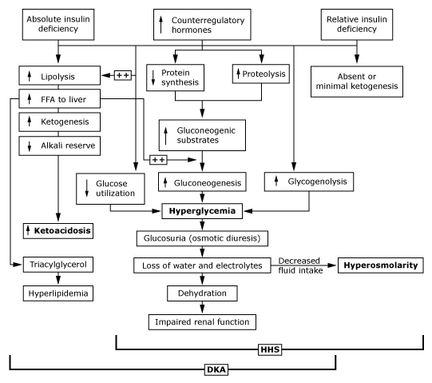

[^6]: image source: 2023 UpToDate, Inc. and/or its affiliates. All Rights Reserved.

## Management

### Typical deficits in DKA<sup>1</sup>

- Water: 100 ml/kg
- Sodium: 7-10 mmol/kg
- Chloride: 3-5 mmol/kg
- Potassium: 3-5 mmol/kg
[^7]: Joint British Diabetes Societies for Inpatient Care. The management of diabetic ketoacidosis in adults. Mar 2023

## IV fluids<sup>1</sup>

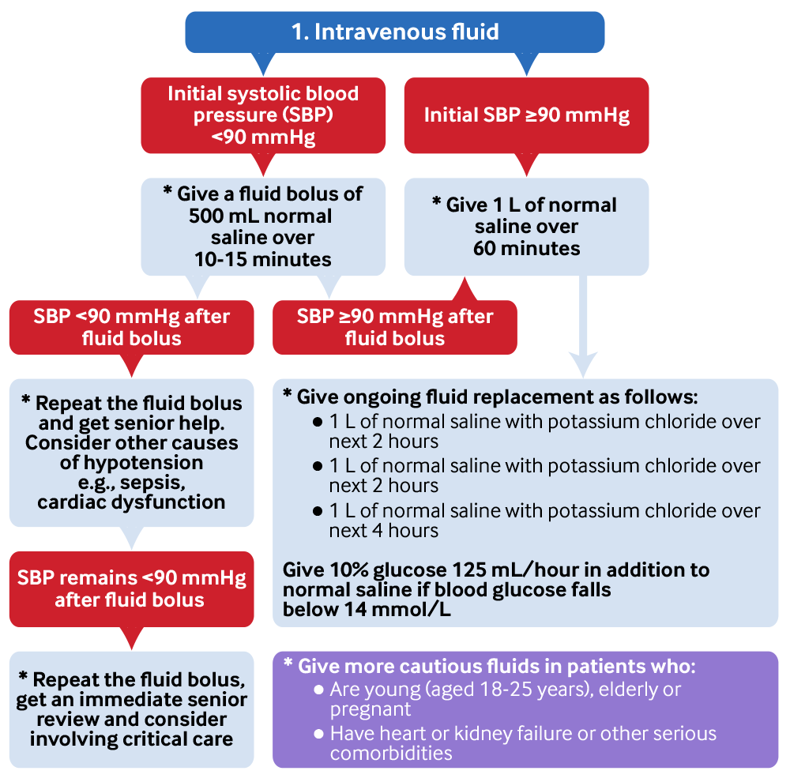

[^8]: image source: BMJ Knowledge Centre

## Potassium algorithm<sup>1</sup>

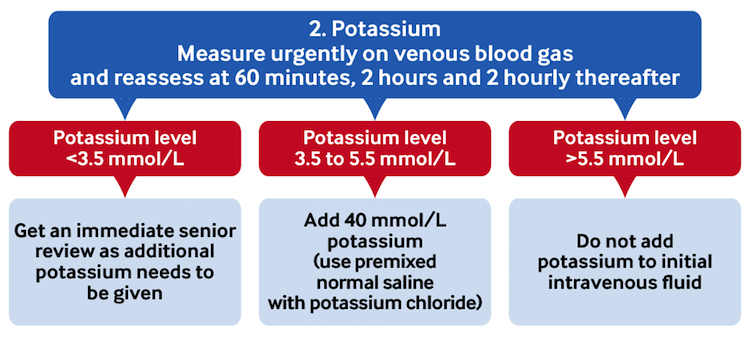

[^9]: image source: BMJ Knowledge Centre

## Insulin algorithm<sup>1</sup>

- fixed rate intravenous insulin infusion (FRIII) at 0.1 units/per kilogram body
- 50 IU soluble human insulin in 49.5 ml 0.9% sodium chloride solution (i.e. 1 unit /ml)
- if RBS <14 mmol/L: add 10% dextrose infusion and consider reducing the rate of intravenous insulin infusion to 0.05 units/kg/hr to avoid the risk of developing hypoglycaemia and hypokalaemia
[^10]: Joint British Diabetes Societies for Inpatient Care. The management of diabetic ketoacidosis in adults. Mar 2023

## Basal insulin

- In those already on long acting basal insulin, it should continue to be prescribed at their usual dose.
- In those newly diagnosed, then a long acting basal insulin should be commenced, at a dose of 0.25 units/Kg subcutaneously once daily

## Treatment targets<sup>1</sup>

- Reduction of the blood ketone concentration by 0.5 mmol/L/hour
- Increase the venous bicarbonate by 3.0 mmol/L/hour
- Reduce capillary blood glucose by 3.0 mmol/L/hour
- Maintain potassium between 4.0 and 5.5 mmol/L

If not achieving targets: double FRIII?

[^11]: Joint British Diabetes Societies for Inpatient Care. The management of diabetic ketoacidosis in adults. Mar 2023

## Resolution of DKA<sup>1</sup>

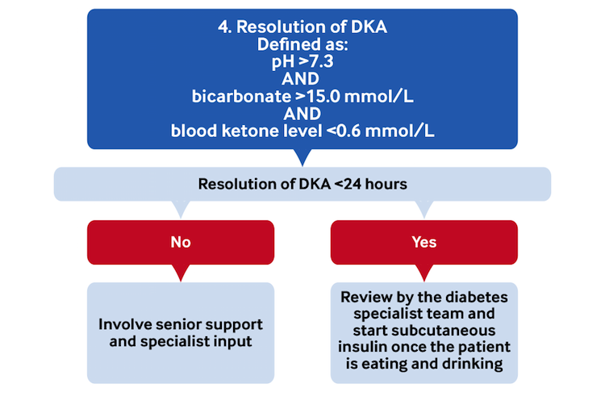

[^12]: image source: BMJ Knowledge Centre

## Finally

- Switch to subcutaneous insulin once DKA has resolved and the patient is eating and drinking
- Start subcutaneous insulin with a meal and continue the FRIII for 30 to 60 minutes after this.